# EGFRmSig: A Tutorial for Applying an EGFR Mutation Signature Score

Minjeong Kim and Miyeon Yeon

2026-01-29

# 1 Overview

*Kim et al. (2025)* introduced a family of centroid-based predictors for mutant (mt) versus wild-type (WT) using the Classification to the Nearest Centroids (ClaNC) method. *EGFRmSig* demonstrates this approach to calculate an EGFR mutation signature (mSig) score, including data preprocessing and distance-based prediction. For detailed background of the methods, please see the reference paper.

Kim M, Lamlertthon W, Jo H, et al. Lung Adenocarcinoma Just Desserts: An Expanding Pie of Activating Oncogenes or a Layer Cake of Integrated Alterations. *bioRxiv* 2025. https://doi.org/10.1101/2025.09.19.677365

# 2 Datasets

First, let’s load *EGFRmSig* and check the structure of two datasets provided in the package.

```r
library(EGFRmSig)
```

## 2.1 `All_subtypes_centroids`

A matrix of predefined centroids for 1,020 genes and 10 mean values. The centroids are averaged by mutation status for subtype-adjusted, subtype-unadjusted, and subtype-specific values in z-score space.

- Notation
  - $g$: gene
  - $i$: sample
  - $x_{g,i}$: expression for gene $g$ and sample $i$
  - $s \in \{bronch, mag, sqm\}$: LUAD expression subtype (bronch, bronchioid; mag, magnoid; sqm, squamoid)
  - $y \in \{WT, mt\}$: EGFR mutation status (WT, wild-type; mt, mutant)
  - $n_y = |\mathscr{I}_{y}|,$ where $\mathscr{I}_{y}$ denotes all samples with mutation status $y$
  - $n_{s,y} = |\mathscr{I}_{s,y}|,$ where $\mathscr{I}_{s,y}$ denotes samples with subtype $s$ and mutation status $y$
- `mean_subtype.i_*`: subtype-adjusted centroids (equal weights)
  $$\mu^{\mathrm{subtype.i}}_{g,y}
  =
  \frac{1}{|\mathscr{S}|}
  \sum_{s \in \mathscr{S}}
  \left(
  \frac{1}{n_{s,y}}
  \sum_{i \in \mathscr{I}_{s,y}}
  x_{g,i}
  \right)
  =
  \sum_{s \in \mathscr{S}}
  \frac{1}{|\mathscr{S}|}
  \mu_{g,y}^s$$
- `mean_all_*`: subtype-unadjusted centroids (subtype-weighted)
  $$\mu^{\mathrm{all}}_{g,y}
  =
  \frac{1}{n_y}
  \sum_{i \in \mathscr{I}_y}
  x_{g,i}
  =
  \sum_{s \in \mathscr{S}}
  \frac{n_{s,y}}{n_y}
  \mu_{g,y}^s$$
- `mean_{subtype}_*`: subtype-specific centroids
  $$\mu^{s}_{g,y}
  =
  \frac{1}{n_{s,y}}
  \sum_{i \in \mathscr{I}_{s,y}}
  x_{g,i}$$

```r
data("All_subtypes_centroids")
str(All_subtypes_centroids)
```

```
#>  num [1:1020, 1:10] -0.00641 -0.09077 -0.09828 0.02295 -0.08542 ...
#>  - attr(*, "dimnames")=List of 2
#>   ..$ : chr [1:1020] "HIP1" "PIGQ" "C16orf58" "UPK3A" ...
#>   ..$ : chr [1:10] "mean_subtype.i_wt" "mean_subtype.i_mt" "mean_all_wt" "mean_all_mt" ...
```

## 2.2 `TOY_expr`

An example expression matrix derived from RSEM TPM values, where rows and columns correspond to 1,000 gene symbols and 50 sample IDs, respectively. The toy dataset was generated to illustrate the analysis workflow and does not contain identifiable or controlled-access data.

```r
data("TOY_expr")
str(TOY_expr)
```

```
#>  num [1:1000, 1:50] 199.6007 1097.2179 3654.4478 21.9136 -0.0353 ...
#>  - attr(*, "dimnames")=List of 2
#>   ..$ : chr [1:1000] "RECK" "THOC3" "SCRN1" "TMEM151A" ...
#>   ..$ : chr [1:50] "T01" "T02" "T03" "T04" ...
```

# 3 Demo

`compute_mSig()` function computes the predicted EGFR mSig score using a RSEM TPM matrix and predefined LUAD centroids. `expr` is required, and the default `centroids` parameter is given as the `All_subtypes_centroids` data in *EGFRmSig*. This function presents the number of overlapping genes and the saved file location (if `export=TRUE`).

## 3.1 Preprocessing

Log-transformed expression values are scaled on a gene-wise basis. `meanCol` is the centroid column to use, and two options are available: `"subtype.i"` (subtype-adjusted centroids) or `"all"` (subtype-unadjusted centroids). The latter is a default setting.

## 3.2 Distance-based prediction

After comparing each sample to WT centroid and mt centroid using Euclidean distance, assign the nearest centroid. The output table is a samples x 3 data frame containing:

- `SampleID`: sample IDs
- `EGFR_mSig_class`: EGFR_mSig_WT_like (pred.ind=1), EGFR_mSig_mut_like (pred.ind=2)
- `EGFR_mSig_distance`: predicted EGFR mSig distance (pred.score)

```r
compute_mSig(expr=TOY_expr)
# Overlapping genes (n_genes_used): 43
# Output saved to: ./Pred_mSig_yyyy-mm-dd.txt
```

# 4 Real Data Analysis

Suppose that we have `TCGA_expr`, a 20,501 x 576 matrix from TCGA-LUAD. The `compute_mSig()` function with `export=FALSE` returns calculation results to the `res` object. The table presents a summary of EGFR mSig distance for TCGA-LUAD samples by class.

```r
# TCGA expression matrix is assumed to be preloaded
# (not included due to data sharing restrictions)
res <- compute_mSig(expr=TCGA_expr, export=FALSE)

library(dplyr)
res %>%
  group_by(EGFR_mSig_class) %>%
  summarise(
    n      = n(),
    min    = min(EGFR_mSig_distance, na.rm=TRUE),
    q1     = quantile(EGFR_mSig_distance, 0.25, na.rm=TRUE),
    median = median(EGFR_mSig_distance, na.rm=TRUE),
    mean   = mean(EGFR_mSig_distance, na.rm=TRUE),
    q3     = quantile(EGFR_mSig_distance, 0.75, na.rm=TRUE),
    max    = max(EGFR_mSig_distance, na.rm=TRUE)
  )
# # A tibble: 2 × 8
# EGFR_mSig_class        n   min    q1 median  mean    q3   max
# <chr>              <int> <dbl> <dbl>  <dbl> <dbl> <dbl> <dbl>
#   1 EGFR_mSig_WT_like    455  297.  649.   800.  949. 1125. 3951.
# 2 EGFR_mSig_mut_like   121  254.  572.   679.  759.  860. 2014.
```

`plot_mSig()` function plots the distribution of EGFR mSig distance by class using violin/boxplot from the output object `res` returned by `compute_mSig()`. In the figure, EGFR mSig WT-like samples show a higher median and a larger IQR with long right-tail distribution, suggesting transcriptomic heterogeneity.

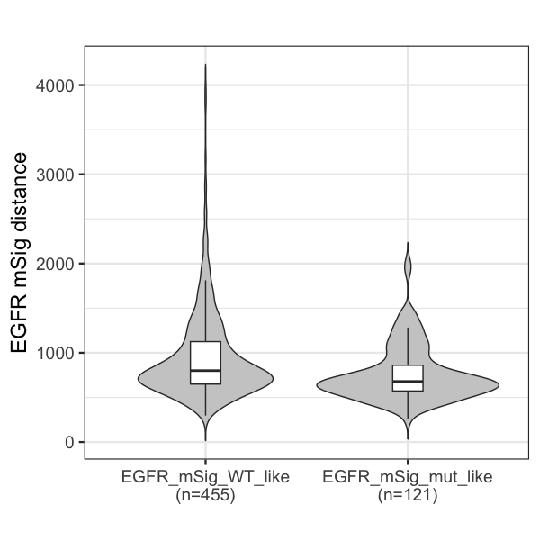

```r
library(ggplot2)
plot_mSig(res=res)
```